# ANALYZING Nephila male VO2, performance, and predicted fitness

## General housekeeping

First load the libraries that we are using

```r
library(lme4)
library(lmerTest)
```

```r
library(ggplot2)
library(knitr)
library(plyr)
library(PerformanceAnalytics)
```

Next load the functions that we’ll use for summary data

Using the script written here: http://www.r-bloggers.com/more-on-exploring-correlations-in-r/ to create the correlation data for the table, but also to create a figure of correlation values

See http://goo.gl/nahmV for documentation of this function

```r
cor.prob <- function (X, dfr = nrow(X) - 2) {
  R <- cor(X, use="pairwise.complete.obs")
  above <- row(R) < col(R)
  r2 <- R[above]^2
  Fstat <- r2 * dfr/(1 - r2)
  R[above] <- 1 - pf(Fstat, 1, dfr)
  R[row(R) == col(R)] <- NA
  R
}
```

Use this function to dump the cor.prob output to a 4 column matrix with row/column indices, correlation, and p-value. See StackOverflow question: http://goo.gl/fCUcQ

```r
flattenSquareMatrix <- function(m) {
  if( (class(m) != "matrix") | (nrow(m) != ncol(m))) stop("Must be a square matrix.")
  if(!identical(rownames(m), colnames(m))) stop("Row and column names must be equal.")
  ut <- upper.tri(m)
  data.frame(i = rownames(m)[row(m)[ut]],
             j = rownames(m)[col(m)[ut]],
             cor=t(m)[ut],
             p=m[ut])
}
```

Use this one for summary statistics

```r
my.summary <- function(x, na.rm=TRUE){
  result <- c(Mean=mean(x, na.rm=na.rm),
              SD=sd(x, na.rm=na.rm),
              Median=median(x, na.rm=na.rm),
              Min=min(x, na.rm=na.rm),
              Max=max(x, na.rm=na.rm),
              N=length(x))
}
```

```r
data = read.table(file.choose(),  na.strings =".", header=T, sep=",")
```

Delete MV37, SV12 & SV14 as they were missing legs after the metabolic analysis and we don’t have measurements for MV37 and don’t have physiological measurements as we stopped them because they lost enough legs (SV12, SV14)

```r
data<-data[-which(is.na(data$Ceph)),]
data<-data[-which(is.na(data$Rest_slope)),]
```

Delete Rows that are missing values in ‘Trial’ to subset individuals that were used in the mate choice trials

```r
data2<-data[-which(is.na(data$trial)),]
```

First scale all the independent variables to create z-scores

```r
data2$zleg <- scale(data2$leg, center = TRUE, scale=TRUE)
data2$zceph <- scale(data2$Ceph, center = TRUE, scale=TRUE)
data2$zweight <- scale(data2$Weight, center = TRUE, scale=TRUE)
data2$zvolspeedmax <- scale(data2$Vol_speed_max, center = TRUE, scale=TRUE)
data2$zforcedspeedmax <- scale(data2$Forced_speed_max, center = TRUE, scale=TRUE)
data2$zresting <- scale(data2$Resting, center = TRUE, scale=TRUE)
data2$zactive <- scale(data2$Active, center = TRUE, scale=TRUE)
data2$zscope <- scale(data2$Scope, center = TRUE, scale=TRUE)
data2$zvolspeedmean <- scale(data2$Vol_speed_mean, center = TRUE, scale=TRUE)
data2$zforcedspeedmean <- scale(data2$Forced_speed_mean, center = TRUE, scale=TRUE)
```

## Exploring the data’

Check to see if there is a difference in the morphological or physiological variables of individuals that did or did not survive until the next day.

```r
DeathCeph <- aov(Ceph ~ Died, data=data)
summary(DeathCeph)
```

```
##             Df Sum Sq Mean Sq F value Pr(>F)
## Died         1   0.40  0.3953   0.303  0.584
## Residuals   70  91.38  1.3055
```

```r
DeathLeg <- aov(leg ~ Died, data=data)
summary(DeathLeg)
```

```
##             Df Sum Sq Mean Sq F value Pr(>F)
## Died         1    1.6   1.597   0.083  0.775
## Residuals   70 1353.7  19.339
```

```r
DeathWeight <- aov(Weight ~ Died, data=data)
summary(DeathWeight)
```

```
##             Df   Sum Sq   Mean Sq F value Pr(>F)
## Died         1 0.000958 0.0009576   3.236 0.0763 .
## Residuals   70 0.020713 0.0002959
## ---
## Signif. codes:  0 '***' 0.001 '**' 0.01 '*' 0.05 '.' 0.1 ' ' 1
```

```r
ddply(data,~Died,summarise,mean=mean(Weight),sd=sd(Weight))
```

```
##   Died       mean          sd
## 1   No 0.01596667 0.005043076
## 2  Yes 0.02494667 0.037118360
```

```r
DeathScope <- aov(Scope ~ Died + Weight, data=data)
summary(DeathScope)
```

```
##             Df    Sum Sq   Mean Sq F value Pr(>F)
## Died         1 7.000e-10 6.570e-10   0.110  0.741
## Weight       1 1.500e-09 1.488e-09   0.249  0.620
## Residuals   69 4.131e-07 5.987e-09
```

get the columns that you want from the dataset then create a correlation matrix then get the p-values using the above function “flatten”" theat table using the above function

```r
corrdata2 <- data2[, c(26,28,33,34,30)]
cor(corrdata2)
```

```
##                         zleg     zweight      zscope zvolspeedmean
## zleg             1.000000000  0.87406632  0.11173360  -0.006551121
## zweight          0.874066322  1.00000000  0.18019463  -0.034947794
## zscope           0.111733596  0.18019463  1.00000000  -0.117065788
## zvolspeedmean   -0.006551121 -0.03494779 -0.11706579   1.000000000
## zforcedspeedmax  0.223411663  0.20100096  0.02945084   0.458476955
##                 zforcedspeedmax
## zleg                 0.22341166
## zweight              0.20100096
## zscope               0.02945084
## zvolspeedmean        0.45847696
## zforcedspeedmax      1.00000000
```

```r
cor.prob(corrdata2)
```

```
##                         zleg     zweight      zscope zvolspeedmean
## zleg                      NA  0.00000000  0.40796686     0.9614257
## zweight          0.874066322          NA  0.17982024     0.7963426
## zscope           0.111733596  0.18019463          NA     0.3858139
## zvolspeedmean   -0.006551121 -0.03494779 -0.11706579            NA
## zforcedspeedmax  0.223411663  0.20100096  0.02945084     0.4584770
##                 zforcedspeedmax
## zleg               0.0948123761
## zweight            0.1338083185
## zscope             0.8278420592
## zvolspeedmean      0.0003350349
## zforcedspeedmax              NA
```

```r
flattenSquareMatrix(cor.prob(corrdata2))
```

```
##                i               j          cor            p
## 1           zleg         zweight  0.874066322 0.0000000000
## 2           zleg          zscope  0.111733596 0.4079668634
## 3        zweight          zscope  0.180194626 0.1798202441
## 4           zleg   zvolspeedmean -0.006551121 0.9614256651
## 5        zweight   zvolspeedmean -0.034947794 0.7963425592
## 6         zscope   zvolspeedmean -0.117065788 0.3858139455
## 7           zleg zforcedspeedmax  0.223411663 0.0948123761
## 8        zweight zforcedspeedmax  0.201000964 0.1338083185
## 9         zscope zforcedspeedmax  0.029450840 0.8278420592
## 10 zvolspeedmean zforcedspeedmax  0.458476955 0.0003350349
```

Finally, plot the data for Figure 1

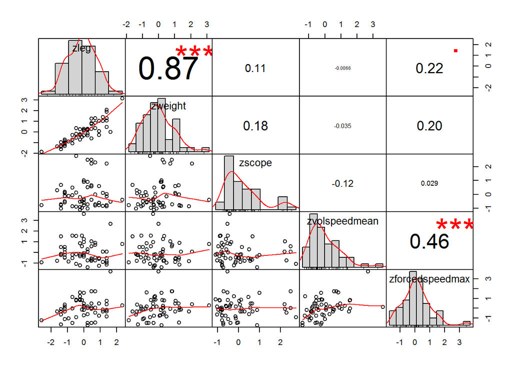

```r
options(warn=-1)
chart.Correlation(corrdata2)
```

```r
options(warn=0)
```

Using a MANOVA to examine whether any of the performance variables are affected by morphological (size, weight) and physiological (scope) traits.

```r
performance_running1 <- manova(cbind(zvolspeedmean, zforcedspeedmax) ~ zscope + zleg + zweight, data=data2)
summary(performance_running1, test="Pillai")
```

```
##           Df   Pillai approx F num Df den Df Pr(>F)
## zscope     1 0.023044  0.61329      2     52 0.5454
## zleg       1 0.061062  1.69085      2     52 0.1943
## zweight    1 0.002923  0.07622      2     52 0.9267
## Residuals 53
```

No significance of anything. Below are univariate results just to see if there is any other effect

```r
summary.aov(performance_running1)
```

```
##  Response 1 :
##             Df Sum Sq Mean Sq F value Pr(>F)
## zscope       1  0.767 0.76745  0.7377 0.3943
## zleg         1  0.002 0.00242  0.0023 0.9617
## zweight      1  0.093 0.09293  0.0893 0.7662
## Residuals   53 55.137 1.04032
##
##  Response 2 :
##             Df Sum Sq Mean Sq F value Pr(>F)
## zscope       1  0.049 0.04857  0.0484 0.8267
## zleg         1  2.748 2.74769  2.7375 0.1039
## zweight      1  0.007 0.00699  0.0070 0.9338
## Residuals   53 53.197 1.00371
```

It seems that none of the factors predict any aspect of performance

Now check to see if any of the morphological, physiological, or performance variables affect whether a male found a female or the estimated fitness

But will run a GLM with trial as a random effect as males shared a trial and another males success may have been dependent upon another male

```r
Found <- glmer(Found_female ~ zvolspeedmean + zforcedspeedmax + zscope + zleg + zweight + (1|trial), data = data2, family=binomial, control = glmerControl(optimizer = "bobyqa"))

summary(Found)
```

```
## Generalized linear mixed model fit by maximum likelihood (Laplace
##   Approximation) [glmerMod]
##  Family: binomial  ( logit )
## Formula: Found_female ~ zvolspeedmean + zforcedspeedmax + zscope + zleg +
##     zweight + (1 | trial)
##    Data: data2
## Control: glmerControl(optimizer = "bobyqa")
##
##      AIC      BIC   logLik deviance df.resid
##     69.5     83.8    -27.8     55.5       50
##
## Scaled residuals:
##     Min      1Q  Median      3Q     Max
## -2.0735 -0.8953  0.3100  0.6352  1.3521
##
## Random effects:
##  Groups Name        Variance Std.Dev.
##  trial  (Intercept) 0        0
## Number of obs: 57, groups:  trial, 6
##
## Fixed effects:
##                 Estimate Std. Error z value Pr(>|z|)
## (Intercept)      1.41559    0.42176   3.356  0.00079 ***
## zvolspeedmean    1.39696    0.60512   2.309  0.02097 *
## zforcedspeedmax -0.02916    0.41870  -0.070  0.94448
## zscope          -0.18527    0.33818  -0.548  0.58380
## zleg            -0.02145    0.74701  -0.029  0.97710
## zweight          0.11520    0.81051   0.142  0.88697
## ---
## Signif. codes:  0 '***' 0.001 '**' 0.01 '*' 0.05 '.' 0.1 ' ' 1
##
## Correlation of Fixed Effects:
##             (Intr) zvlspd zfrcds zscope zleg
## zvolspeedmn  0.594
## zforcdspdmx -0.017 -0.323
## zscope      -0.086  0.010 -0.062
## zleg         0.144  0.197  0.156  0.110
## zweight     -0.111 -0.130 -0.249 -0.177 -0.894
```

Now let’s check if the amount of time it took to find a female is predicted by anything

```r
Time <- lmer(Time_find ~ zvolspeedmean + zforcedspeedmax + zscope + zleg + zweight + (1|trial), data = data2)

summary(Time)
```

```
## Linear mixed model fit by REML t-tests use Satterthwaite approximations
##   to degrees of freedom [merModLmerTest]
## Formula: Time_find ~ zvolspeedmean + zforcedspeedmax + zscope + zleg +
##     zweight + (1 | trial)
##    Data: data2
##
## REML criterion at convergence: 323.2
##
## Scaled residuals:
##     Min      1Q  Median      3Q     Max
## -1.9922 -0.7668 -0.1105  0.5100  1.9016
##
## Random effects:
##  Groups   Name        Variance Std.Dev.
##  trial    (Intercept)  19.41    4.406
##  Residual             250.67   15.832
## Number of obs: 42, groups:  trial, 6
##
## Fixed effects:
##                 Estimate Std. Error     df t value Pr(>|t|)
## (Intercept)       19.019      3.089  5.070   6.156  0.00157 **
## zvolspeedmean      1.938      2.783 34.590   0.696  0.49081
## zforcedspeedmax    3.212      2.921 30.410   1.100  0.28014
## zscope             2.960      2.749 32.880   1.077  0.28943
## zleg              -6.555      5.741 35.920  -1.142  0.26112
## zweight            4.265      5.366 36.000   0.795  0.43195
## ---
## Signif. codes:  0 '***' 0.001 '**' 0.01 '*' 0.05 '.' 0.1 ' ' 1
##
## Correlation of Fixed Effects:
##             (Intr) zvlspd zfrcds zscope zleg
## zvolspeedmn -0.152
## zforcdspdmx  0.018 -0.500
## zscope       0.034  0.069  0.036
## zleg         0.056 -0.055 -0.105  0.095
## zweight     -0.064  0.109 -0.022 -0.202 -0.855
```

Now check to see if estimated paternity (based on the distance to the female and the relative number of rivales) is determined by any of the above variables

```r
Fitness <- lmer(Est_paternity ~ zvolspeedmean + zforcedspeedmax + zscope + zleg + zweight + (1|trial), data = data2)

summary(Fitness)
```

```
## Linear mixed model fit by REML t-tests use Satterthwaite approximations
##   to degrees of freedom [merModLmerTest]
## Formula:
## Est_paternity ~ zvolspeedmean + zforcedspeedmax + zscope + zleg +
##     zweight + (1 | trial)
##    Data: data2
##
## REML criterion at convergence: 505.5
##
## Scaled residuals:
##      Min       1Q   Median       3Q      Max
## -1.62560 -0.63509  0.01315  0.35986  2.46309
##
## Random effects:
##  Groups   Name        Variance Std.Dev.
##  trial    (Intercept)   0       0.00
##  Residual             762      27.61
## Number of obs: 57, groups:  trial, 6
##
## Fixed effects:
##                 Estimate Std. Error     df t value Pr(>|t|)
## (Intercept)       34.018      3.656 51.000   9.304 1.43e-12 ***
## zvolspeedmean      7.544      4.229 51.000   1.784   0.0804 .
## zforcedspeedmax   -4.110      4.305 51.000  -0.955   0.3442
## zscope             3.345      3.797 51.000   0.881   0.3825
## zleg              -1.205      7.667 51.000  -0.157   0.8757
## zweight            8.052      7.718 51.000   1.043   0.3017
## ---
## Signif. codes:  0 '***' 0.001 '**' 0.01 '*' 0.05 '.' 0.1 ' ' 1
##
## Correlation of Fixed Effects:
##             (Intr) zvlspd zfrcds zscope zleg
## zvolspeedmn  0.000
## zforcdspdmx  0.000 -0.477
## zscope       0.000  0.125 -0.062
## zleg         0.000  0.010 -0.093  0.096
## zweight      0.000  0.053 -0.035 -0.163 -0.866
```

voluntary running speed is nearly significant.

On average, what was the proportion of their max speed were individuals going? and did that differ between individuals that did and did not find a female?

```r
data2$PropMax <- (data2$Vol_speed_mean/data2$Forced_speed_max)

mean(data2$PropMax)
```

```
## [1] 0.2727658
```

```r
sd(data2$PropMax)/sqrt(length(data2$PropMax))
```

```
## [1] 0.01511486
```

```r
PropMaxDiff <- lm(PropMax~Found_female, data=data2)
summary(PropMaxDiff)
```

```
##
## Call:
## lm(formula = PropMax ~ Found_female, data = data2)
##
## Residuals:
##      Min       1Q   Median       3Q      Max
## -0.20394 -0.08199 -0.02208  0.05585  0.36333
##
## Coefficients:
##               Estimate Std. Error t value Pr(>|t|)
## (Intercept)    0.23035    0.02897   7.950 1.05e-10 ***
## Found_femaleY  0.05757    0.03375   1.705   0.0937 .
## ---
## Signif. codes:  0 '***' 0.001 '**' 0.01 '*' 0.05 '.' 0.1 ' ' 1
##
## Residual standard error: 0.1122 on 55 degrees of freedom
## Multiple R-squared:  0.05023,    Adjusted R-squared:  0.03296
## F-statistic: 2.909 on 1 and 55 DF,  p-value: 0.09374
```

```r
PropMaxDiff2 <- lm(PropMax~Est_paternity, data=data2)
summary(PropMaxDiff2)
```

```
##
## Call:
## lm(formula = PropMax ~ Est_paternity, data = data2)
##
## Residuals:
##      Min       1Q   Median       3Q      Max
## -0.19397 -0.08451 -0.04098  0.06897  0.37158
##
## Coefficients:
##                Estimate Std. Error t value Pr(>|t|)
## (Intercept)   0.2531743  0.0238582  10.612 6.37e-15 ***
## Est_paternity 0.0005759  0.0005431   1.061    0.294
## ---
## Signif. codes:  0 '***' 0.001 '**' 0.01 '*' 0.05 '.' 0.1 ' ' 1
##
## Residual standard error: 0.114 on 55 degrees of freedom
## Multiple R-squared:  0.02004,    Adjusted R-squared:  0.002222
## F-statistic: 1.125 on 1 and 55 DF,  p-value: 0.2935
```

```r
meanProp <- ddply(data2, .(Found_female), summarize, mean=mean(PropMax), se=sd(PropMax)/sqrt(length(PropMax)))
meanProp
```

```
##   Found_female      mean         se
## 1            N 0.2303471 0.02613792
## 2            Y 0.2879153 0.01785771
```

Is the proportion of their max performance determined by their scope?

```r
PropMaxPerf <- lm(PropMax ~ zscope + zweight, data=data2)
summary(PropMaxPerf)
```

```
##
## Call:
## lm(formula = PropMax ~ zscope + zweight, data = data2)
##
## Residuals:
##      Min       1Q   Median       3Q      Max
## -0.19692 -0.08825 -0.02866  0.05840  0.36466
##
## Coefficients:
##             Estimate Std. Error t value Pr(>|t|)
## (Intercept)  0.27277    0.01484  18.385   <2e-16 ***
## zscope      -0.01290    0.01522  -0.848    0.400
## zweight     -0.02529    0.01522  -1.662    0.102
## ---
## Signif. codes:  0 '***' 0.001 '**' 0.01 '*' 0.05 '.' 0.1 ' ' 1
##
## Residual standard error: 0.112 on 54 degrees of freedom
## Multiple R-squared:  0.07094,    Adjusted R-squared:  0.03653
## F-statistic: 2.062 on 2 and 54 DF,  p-value: 0.1371
```

Nope

plotting some of the factors here.

First voluntary running speed and searching success First recode the y/n into 1/0 This makes Figure 2

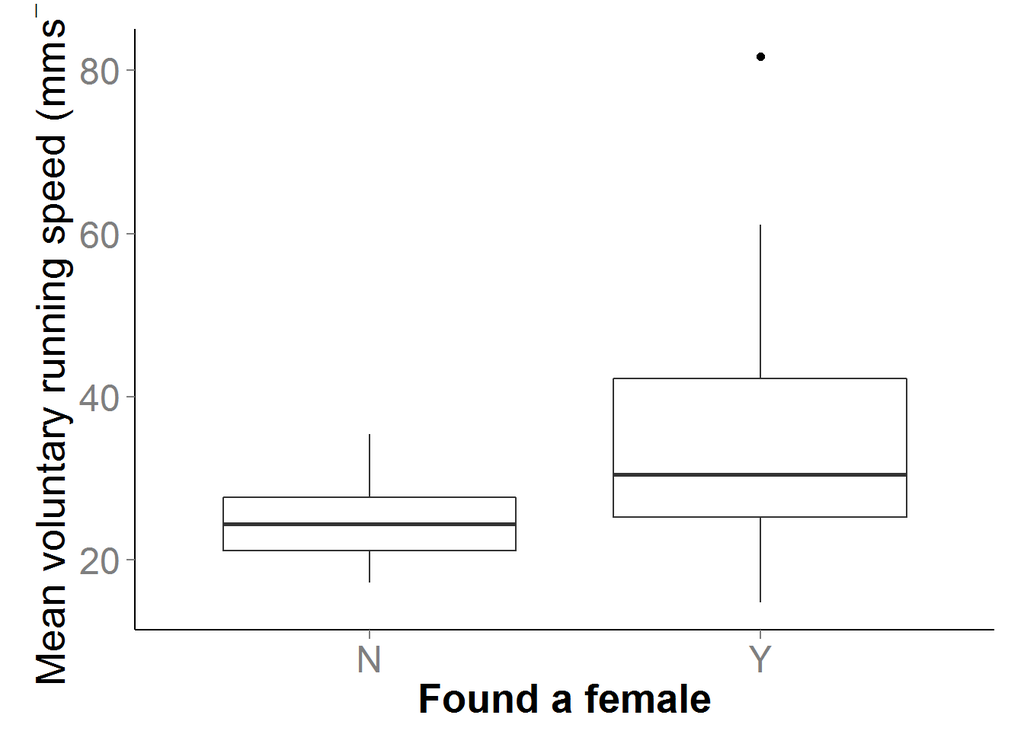

```r
data2$Found2 <- revalue(data2$Found_female, c("Y"="1", "N"="0"))

ggplot(data2, aes(x=Found_female, y=Vol_speed_max)) + geom_boxplot() + guides(fill=FALSE) +
  xlab("Found a female") +
  ylab("Mean voluntary running speed (mm "~s^-1*")") +
  theme(axis.line = element_line(colour = "black"),
        axis.text=element_text(size=18),
        axis.title=element_text(size=20,face="bold"),
        axis.title.y=element_text(vjust=0.50),
        axis.title.x=element_text(vjust=0.25),
        panel.grid.major = element_blank(),
        panel.grid.minor = element_blank(),
        panel.border = element_blank(),
        panel.background = element_blank())
```

Let’s take a look at the relationship between voluntary and forced performance and plot it This makes Figure 3.

```r
MaxPerf <- lm(Vol_speed_mean ~ Forced_speed_max, data=data2)
summary(MaxPerf)
```

```
##
## Call:
## lm(formula = Vol_speed_mean ~ Forced_speed_max, data = data2)
##
## Residuals:
##     Min      1Q  Median      3Q     Max
## -10.808  -3.865  -1.124   3.325  21.815
##
## Coefficients:
##                  Estimate Std. Error t value Pr(>|t|)
## (Intercept)       5.50191    2.26263   2.432 0.018315 *
## Forced_speed_max  0.15524    0.04057   3.826 0.000335 ***
## ---
## Signif. codes:  0 '***' 0.001 '**' 0.01 '*' 0.05 '.' 0.1 ' ' 1
##
## Residual standard error: 5.503 on 55 degrees of freedom
## Multiple R-squared:  0.2102, Adjusted R-squared:  0.1958
## F-statistic: 14.64 on 1 and 55 DF,  p-value: 0.000335
```

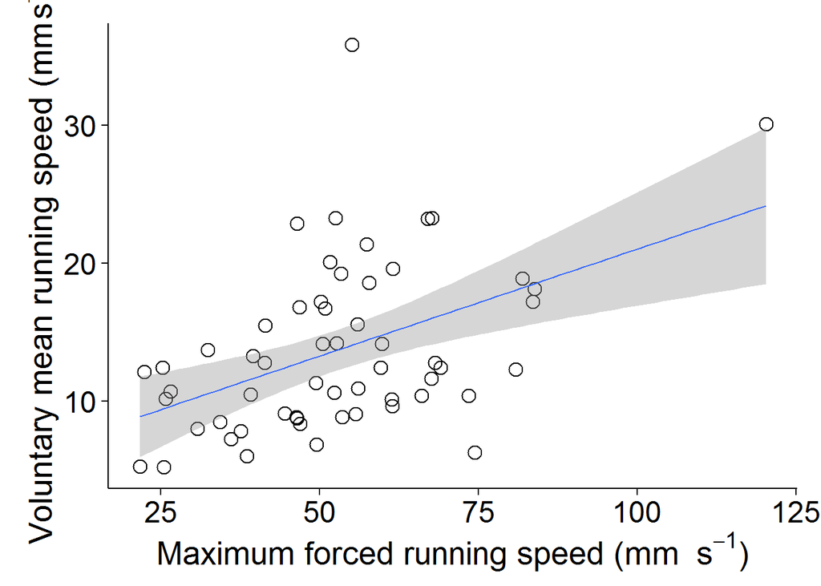

```r
ggplot(data2, aes(x = Forced_speed_max, y = Vol_speed_mean)) + geom_point(shape=1, size=4) +
  theme_bw() + geom_smooth(method=lm, se=TRUE, fullrange=T) +
  xlab("Maximum forced running speed (mm "~s^-1*")") +
  ylab("Voluntary mean running speed (mm "~s^-1*")") +
  theme(axis.line = element_line(colour = "black"),
        axis.text=element_text(size=18),
        axis.title=element_text(size=20,face="bold"),
        axis.title.y=element_text(vjust=0.50),
        axis.title.x=element_text(vjust=0.25),
        panel.grid.major = element_blank(),
        panel.grid.minor = element_blank(),
        panel.border = element_blank(),
        panel.background = element_blank())
```